# How do retirement plans differ across cultures and races?

## Introduction

```r
## set up of the R and data
library(tidyverse)
## we only selected few sub-data sets as they are the ones we want to conduct study on

lifetime_earn <- readr::read_csv('https://raw.githubusercontent.com/rfordatascience/tidytuesday/master/data/2021/2021-02-09/lifetime_earn.csv')
retirement <- readr::read_csv('https://raw.githubusercontent.com/rfordatascience/tidytuesday/master/data/2021/2021-02-09/retirement.csv')
income_time <- readr::read_csv('https://raw.githubusercontent.com/rfordatascience/tidytuesday/master/data/2021/2021-02-09/income_time.csv')
income_distribution <- readr::read_csv('https://raw.githubusercontent.com/rfordatascience/tidytuesday/master/data/2021/2021-02-09/income_distribution.csv')
home_owner <- readr::read_csv('https://raw.githubusercontent.com/rfordatascience/tidytuesday/master/data/2021/2021-02-09/home_owner.csv')
race_wealth <- readr::read_csv('https://raw.githubusercontent.com/rfordatascience/tidytuesday/master/data/2021/2021-02-09/race_wealth.csv')
## And due to consistency of the study, we are only interested in the data from 2006 to 2016,
## therefore, we filtered out the data between 2006 to 2016 and arranged by year

retirement_a = retirement %>% filter(year > 2006) %>% arrange(year)
income_time_a = income_time %>% filter(year > 2006) %>% arrange(year)
income_distribution_a = income_distribution %>% filter(year >2006) %>% arrange(year)
home_owner_a = home_owner %>% filter(year > 2006) %>% arrange(year)
race_wealth_a = race_wealth %>% filter(year > 2006) %>% filter(type == "Average") %>% arrange(year)
```

## Materials and Methods

Our main indicator of an individual’s retirement plan is their retirement savings recorded in the cleaned data set, “retirement”. The data is collected from the Survey of Consumer Finances in the time period of 1989 - 2016 and calculated by the Urban Institute. Approximately 6,500 U.S. families voluntarily participated in the triennial cross-sectional survey conducted by the Federal Reserve Board in cooperation with the Department of the Treasury. The survey data including families’ balance sheets, pensions, income and demographic characteristics were collected by the NORC at the University of Chicago. They were then extracted and cleaned to 30 entries of average family liquid retirement savings normalized to 2016 dollars which cover the dollars in retirement accounts like 401(k), 403 (b), and IRAs, characterized by two other variables, year and race.

## Table 1

```r
retirement_a
```

| year | race | retirement |
| --- | --- | --- |
| 2007 | White | 114264.60 |
| 2007 | Black | 29364.69 |
| 2007 | Hispanic | 23178.79 |
| 2010 | White | 124496.60 |
| 2010 | Black | 19290.86 |
| 2010 | Hispanic | 20058.13 |
| 2013 | White | 138557.50 |
| 2013 | Black | 20440.14 |
| 2013 | Hispanic | 10264.48 |
| 2016 | White | 157884.20 |

[output cut: 2 more lines]

Since wealth is potentially the biggest contributing factor of retirement savings. Another main material is the data set, “race_wealth”. The data is the calculations of Urban Institute from Survey of Financial Characteristics of Consumers 1962, Survey of Changes in Family Finances 1963 and Survey of Consumer Finances 1983 - 2016. The prior two surveys are the precursor of the Survey of Consumer Finances described above. The Survey of Financial Characteristics of Consumers is designed to obtain balance sheet and income data. The Survey of Changes in Family Finances is designed to collect information on changes in assets and liabilities for families across different income levels. Wealth includes assets, savings, real estate, businesses, excluding debts. The cleaned data set consists of 96 rows of U.S. family wealth data normalized to 2016 dollars, accompanied by the measures of central tendency with mean and median and two other categorical data of race and year. ## Table 2

```r
race_wealth_a
```

| type | year | race | wealth_family |
| --- | --- | --- | --- |
| Average | 2007 | Non-White | NA |
| Average | 2007 | White | 802519.8 |
| Average | 2007 | Black | 156285.1 |
| Average | 2007 | Hispanic | 215534.0 |
| Average | 2010 | Non-White | NA |
| Average | 2010 | White | 715067.3 |
| Average | 2010 | Black | 110569.1 |
| Average | 2010 | Hispanic | 128038.7 |
| Average | 2013 | Non-White | NA |
| Average | 2013 | White | 717069.1 |

[output cut: 6 more lines]

Another key contribution to wealth is income. The historical income tables given by the U.S. census bureau is a perfect source. It is joined with the data from the Current Population Survey 1963 - 2017 as described above, credited to Karen Smith. The cleaned dataset, “income_distribution” features the income median, mean, bracket and distribution across categorical variables of year, race, and number of households. The definition of income here is an individual’s private income including earnings, dividends and government monetary benefits.

## Table 3

```r
income_distribution_a
```

| year | race | number | income_median | income_med_moe | income_mean | income_mean_moe | income_bracket | income_distribution |
| --- | --- | --- | --- | --- | --- | --- | --- | --- |
| 2007 | All Races | 116783000 | 62090 | 285 | 83568 | 480 | Under $15,000 | 10.0 |
| 2007 | All Races | 116783000 | 62090 | 285 | 83568 | 480 | $15,000 to $24,999 | 10.0 |
| 2007 | All Races | 116783000 | 62090 | 285 | 83568 | 480 | $25,000 to $34,999 | 9.0 |
| 2007 | All Races | 116783000 | 62090 | 285 | 83568 | 480 | $35,000 to $49,999 | 12.8 |
| 2007 | All Races | 116783000 | 62090 | 285 | 83568 | 480 | $50,000 to $74,999 | 17.3 |
| 2007 | All Races | 116783000 | 62090 | 285 | 83568 | 480 | $75,000 to $99,999 | 12.6 |
| 2007 | All Races | 116783000 | 62090 | 285 | 83568 | 480 | $100,000 to $149,999 | 15.3 |
| 2007 | All Races | 116783000 | 62090 | 285 | 83568 | 480 | $150,000 to $199,999 | 6.7 |
| 2007 | All Races | 116783000 | 62090 | 285 | 83568 | 480 | $200,000 and over | 6.4 |
| 2007 | White Alone | 95112000 | 64417 | 313 | 86932 | 545 | Under $15,000 | 8.4 |

[output cut: 926 more lines]

While on the subject of wealth, real estate ownership is a benchmark of wealth accumulation. The Urban Institute calculated U.S. homeownership rate from Current Population Survey 1976 - 2017. The Census Historical Household Surveys and the Census Annual Statistics contribute the values of 1976 - 2014, and 2016-2016 respectively. It is conducted by the U.S. Census Bureau using a probability selected sample of around 60,000 American households and sponsored by the U.S. Bureau of Labour Statistics (BLS) as the main provider of U.S. labour force statistics. The data is cleaned to 123 rows of homeownership races, categorized by year and race in the data table called “home_owner”.

## Table 4

```r
home_owner_a
```

| year | race | home_owner_pct |
| --- | --- | --- |
| 2007 | White | 0.7207117 |
| 2007 | Black | 0.4816776 |
| 2007 | Hispanic | 0.4930240 |
| 2008 | White | 0.7185634 |
| 2008 | Black | 0.4714453 |
| 2008 | Hispanic | 0.4911912 |
| 2009 | White | 0.7120686 |
| 2009 | Black | 0.4641316 |
| 2009 | Hispanic | 0.4780633 |
| 2010 | White | 0.7101446 |

[output cut: 20 more lines]

## Hypothesis test: Black and Hispanics have lower retirement savings than White.

## Table 5

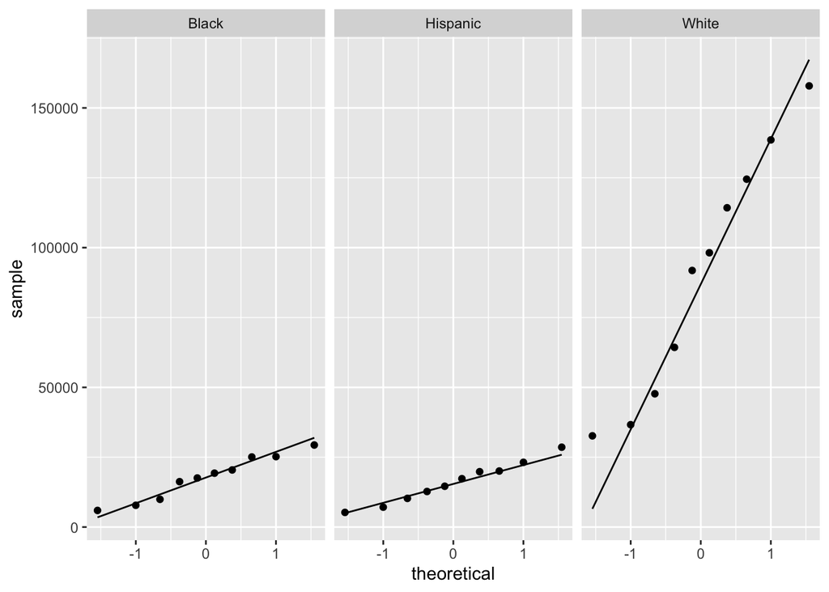

```r
ggplot(retirement, aes(sample = retirement)) + stat_qq() + stat_qq_line() + facet_wrap("race")
```

For White, we can see that the first and last data do not lie on the quantile-quantile line, also there are some outliners. Therefore, we can conclude that White is not normally distributed. We can not use ANOVA and we should use median test for white instead. On the other hand, Black and Hispanic both seem to be normally distributed. Therefore, we have to use median test instead of t-test.

```r
library(smmr)

## create a data set for white people retirement saving
retirement_white <- retirement %>% filter(race == "White")

## create a data set for black people retirement saving
retirement_black <- retirement %>% filter(race == "Black")

## create a data set for Hispanic people retirement saving
retirement_hispanic <- retirement %>% filter(race == "Hispanic")

## find the 95% confidence of white retirement saving median
ci_median(retirement_white, retirement)
```

```
## [1]  36637.76 138557.50
```

So the lower bound of white people retirement saving median is 36637.76

```r
## sign test for black
sign_test(retirement_black, retirement, 36637.76)
```

```
## $above_below
## below above
##    10     0
##
## $p_values
##   alternative      p_value
## 1       lower 0.0009765625
## 2       upper 1.0000000000
## 3   two-sided 0.0019531250
```

The reason I am using lower bound is because lower represent the lowest value of the median under 95% confidence. If the lower bound of white retirement saving is still bigger than the other race retirement saving median, then very likely the actual median of white retirement saving is bigger than other race actual retirement saving median.

H0: Median of Black retirement == lower bound of Median of white retirement saving H1: Median of Black retirement < lower bound of Median of white retirement saving

Since we are testing for “<”, we are looking for the lower test. Since p_value = 0.0009765625 < 0.05, we can easily reject the null at 95% confidence and say that White people has a higher retirement saving.

```r
## sign test for hispanic
sign_test(retirement_hispanic, retirement, 36637.76)
```

```
## $above_below
## below above
##    10     0
##
## $p_values
##   alternative      p_value
## 1       lower 0.0009765625
## 2       upper 1.0000000000
## 3   two-sided 0.0019531250
```

H0: Median of Hispanic retirement == lower bound of Median of white retirement saving H1: Median of Hispanic retirement < lower bound of Median of white retirement saving

Since we are testing for “<”, we are looking for the lower test. Since p_value = 0.0009765625 < 0.05, we can easily reject the null at 95% confidence and say that White people has a higher retirement saving.

## Graphical Interpretation of Wealth Gap

##Table 6

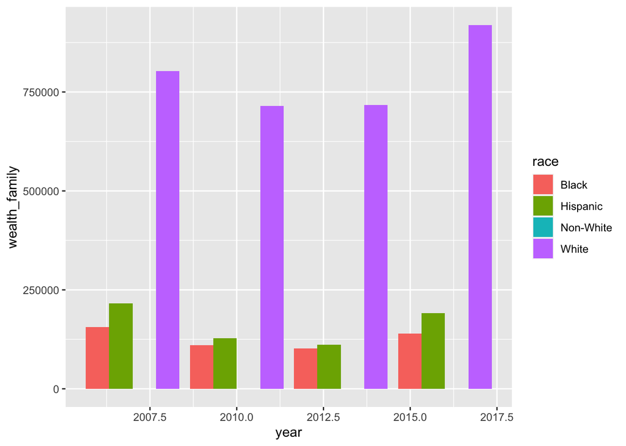

```r
ggplot(race_wealth_a, aes(x = year, y = wealth_family, fill = race)) + geom_bar(stat = "identity", position = "dodge")
```

## Tukey analysis on home_owner_pct

To know if a person is ready to retire, we often want to know if they are owning a house, as renting a house would be pretty expensive and challenging to retired people without income. Therefore, when we study the retirement plan across culture and races, we are curious if housing habit, are they a home owner, is also different. In that, we concluded a tukey test whether the home owner percentage is different among white, hispanic, and black people. First, we plot a normal quantile plots by group to check the validity whether we can conduct a tukey test.

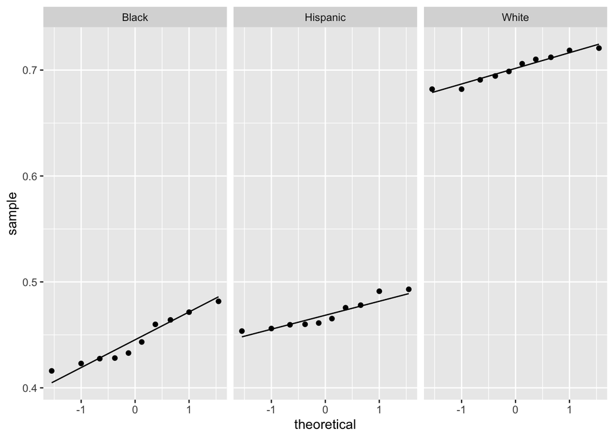

```r
ggplot(home_owner_a, aes(sample = home_owner_pct)) + stat_qq() + stat_qq_line() + facet_wrap( ~ race)
```

```r
home.aov=aov(home_owner_pct~race,data=home_owner_a)
TukeyHSD(home.aov)
```

```
##   Tukey multiple comparisons of means
##     95% family-wise confidence level
##
## Fit: aov(formula = home_owner_pct ~ race, data = home_owner_a)
##
## $race
##                      diff         lwr        upr     p adj
## Hispanic-Black 0.02455612 0.005061248 0.04405099 0.0114318
## White-Black    0.25674069 0.237245820 0.27623556 0.0000000
## White-Hispanic 0.23218457 0.212689700 0.25167944 0.0000000
```

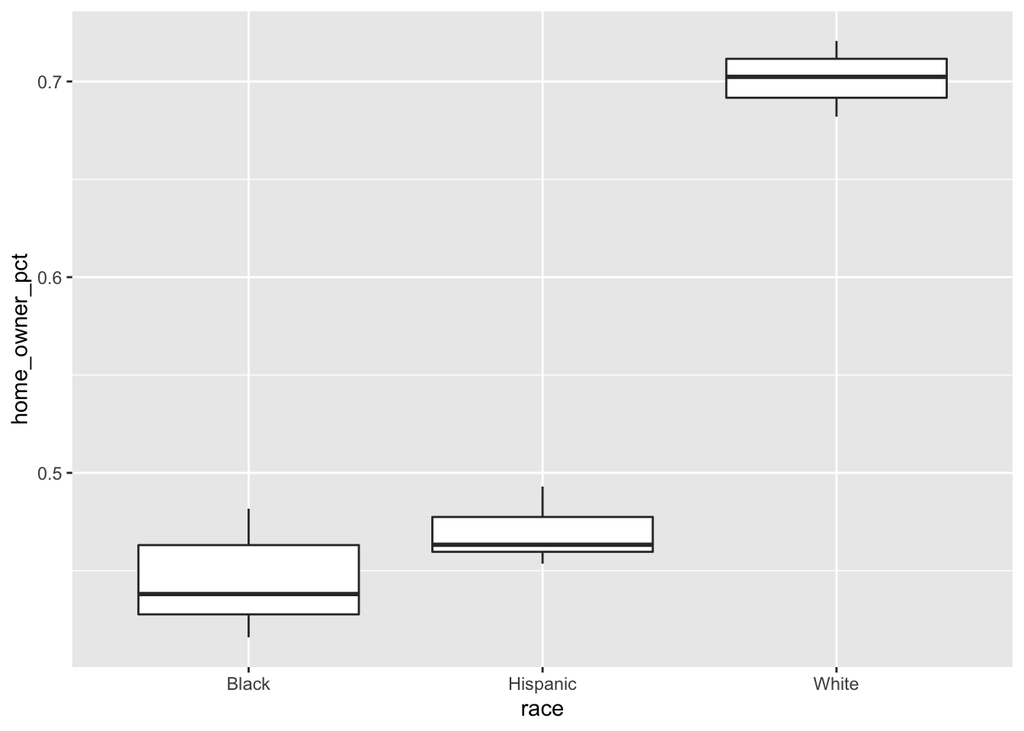

```r
ggplot(home_owner_a, aes(x=race,y=home_owner_pct))+geom_boxplot()
```

From the boxplot and summary above, the home ownership percentage of white ethnic group is higher than the other ethnic groups without doubt. Then hispanic ethnic group is slightly higher than black ethnic group. In that, from home ownership or housing expense perspective, we could conclude that white ethnic group is much more prepared than the other two groups when it comes to retirement. Then, hispanic ethnic group is slightly better prepared than black ethnic group.

Another key contribution to wealth is income. The historical income tables given by the U.S. census bureau is a perfect source. It is joined with the data from the Current Population Survey 1963 - 2017 as described above, credited to Karen Smith. The cleaned dataset, “income_distribution” features the income median, mean, bracket and distribution across categorical variables of year, race, and number of households. The definition of income here is an individual’s private income including earnings, dividends and government monetary benefits.

```r
income_distribution_a_anova = aov(year ~ income_mean, data = income_distribution_a)
summary(income_distribution_a_anova)
```

```
##              Df Sum Sq Mean Sq F value   Pr(>F)
## income_mean   1    745   745.4   56.33 1.43e-13 ***
## Residuals   934  12359    13.2
## ---
## Signif. codes:  0 '***' 0.001 '**' 0.01 '*' 0.05 '.' 0.1 ' ' 1
```

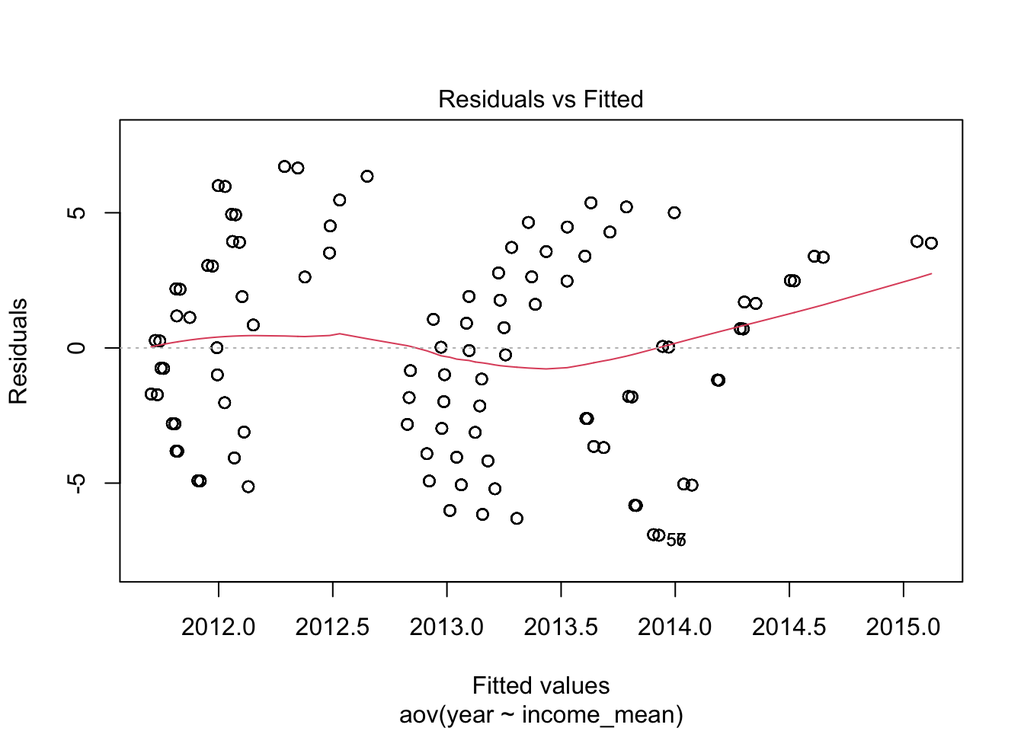

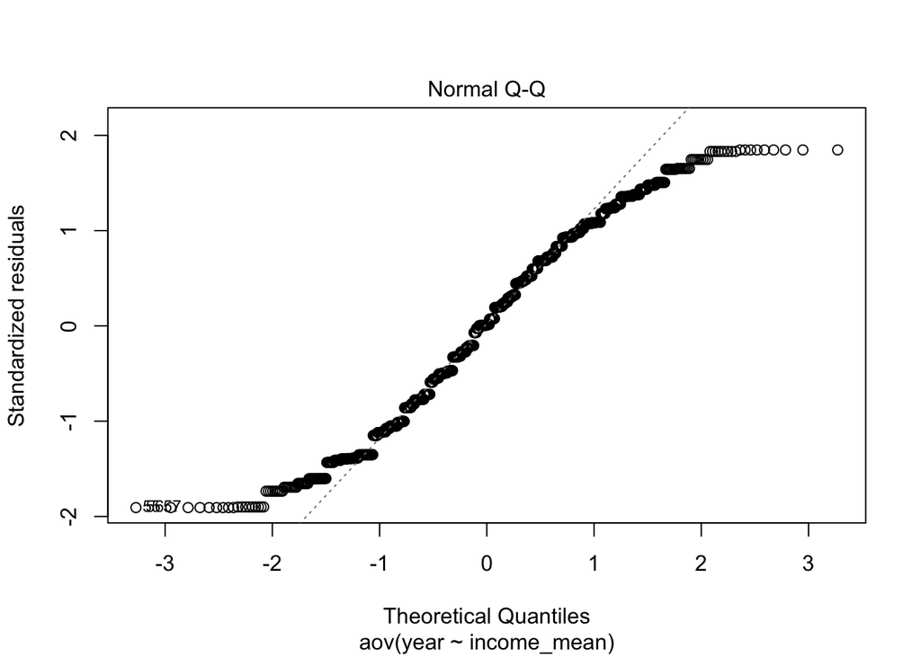

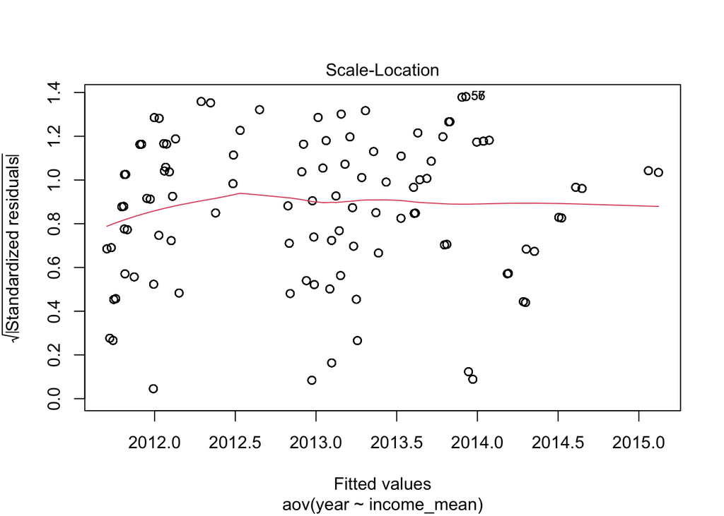

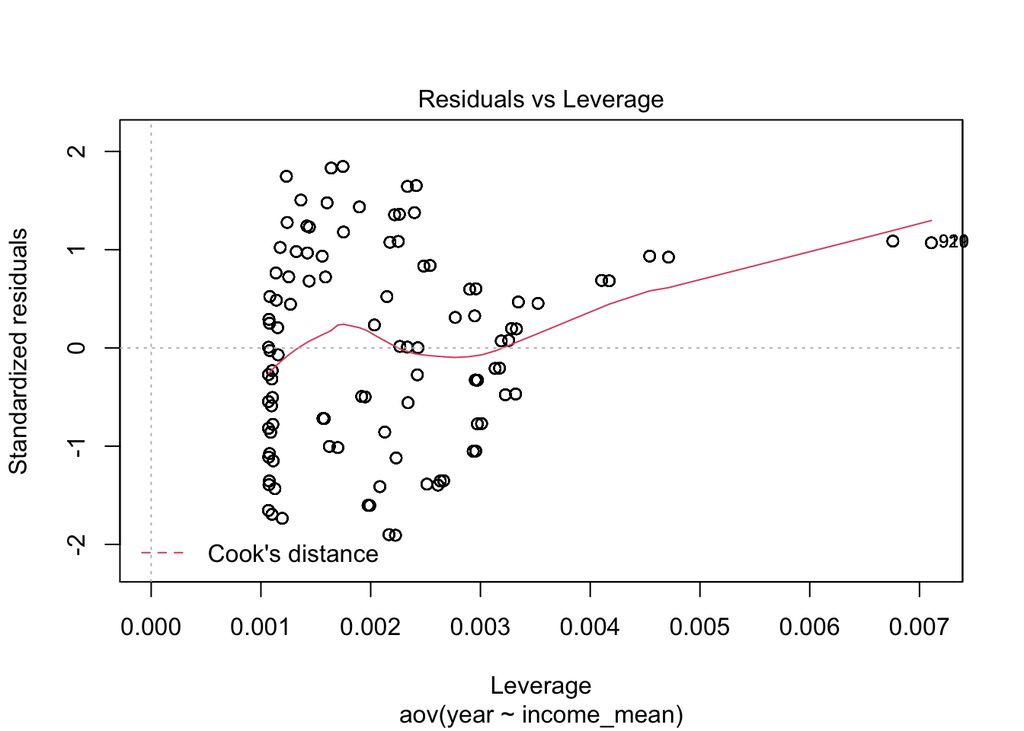

```r
plot(income_distribution_a_anova)
```

## Works Cited

Francis, D. V., & Weller, C. E. (2021). Retirement inequality by race and ethnicity. Public Policy & Aging Report, 31(3), 83-88. Kuan, K. Y., Cullen, M. R., & Modrek, S. (2015). Racial disparities in savings behavior for a continuously employed cohort (No. w20937). National Bureau of Economic Research. Merrill Edge. (2021). How much do you really need to save for retirement? https://www.merrilledge.com/article/how-much-do-you-really-need-to-save-for-retirement Rfordatascience. (2021, February 8). Tidytuesday/readme.md at master · rfordatascience/tidytuesday. GitHub. Retrieved December 7, 2021, from https://github.com/rfordatascience/tidytuesday/blob/master/data/2021/2021-02-09/readme.md.